# PHASE 3: DATA PREPARATION

Thesis TU/e - Automated Valuation Model for Commercial Real Estate

Bas Hilgers | Data: Cushman&Wakefield (confidential)

August 2018

# 1. INTRODUCTION

In the third phase we discuss the *data preparation* process. In it we cover the following actions:

- data transformations
- data integrations
- data filters

We begin with a set of preliminary commands. Specifically, we load the necessary libraries, set our directory paths, turn of scientific formatting.

```r
  ## load Libraries
  library(knitr)      # publication options markdown
  library(tidyverse)  # tidyverse toolkit (dyplr)
  library(RODBC)      # database connection

  ## Set data and code directory
  wd.dir   <- file.path('C:/Users/bashi/Desktop/TUe Thesis')
  data.dir <- file.path(wd.dir, '5 Data', 'AVM database')
  code.dir <- file.path(wd.dir, '6 Modelling', 'modules')

  ## load custom Functions
  source(paste0(code.dir, '/custom_functions_data_preparation.R'))

  ## file options
  options(width=120) # control width output
  knitr::opts_chunk$set(out.width='800px', dpi=200) # control width figures
  options(scipen=999)
  options(stringsAsFactors = FALSE)
```

We then set the path to our active database and establish a connection to it.

```r
  ## get raw data from database
  db.conn <- odbcConnectAccess2007(file.path(data.dir, 'AVM_database.accdb'))
  df_XL <- sqlFetch(db.conn, "tbl2_data_managed_AVM")
```

Eyeball the raw data we are working with.

```r
  ## variables + types
  str(df_XL, list.len=ncol(df_XL))
```

[output not shown]

We also look at the number of missing variables per variable.

```r
  ## table missing values
  missing_values <- sapply(df_XL, function(y) sum(length(which(is.na(y)))))
  missing_values <- data.frame(missing_values, perc = missing_values/nrow(df_XL)*100)
  missing_values <- missing_values[order(missing_values$perc),]
  missing_values
```

```
##                         missing_values         perc
## BOG_ID                               0   0.00000000
## purchase_price_net                   0   0.00000000
## price_per_sqm                        0   0.00000000
## purchase_price_gross                 0   0.00000000
## transfer_date                        0   0.00000000
## portfolio                            0   0.00000000
## latitude                             0   0.00000000
## longitude                            0   0.00000000
## provincie                            0   0.00000000
## city                                 0   0.00000000
## address_complete                     0   0.00000000
## CW_district_ID                       0   0.00000000
## CW_district_name                     0   0.00000000
## CW_district_type                     0   0.00000000
## streetname                           0   0.00000000
## housenumber                          0   0.00000000
## postcode                             0   0.00000000
## year_of_construction                 0   0.00000000
## total_LFA                            0   0.00000000
## city_category                        0   0.00000000
## centrality                           0   0.00000000
## walkscore                            0   0.00000000
## lbm_total_score                      0   0.00000000
## lbm_woningen                         0   0.00000000
## lbm_bewoners                         0   0.00000000
## lbm_voorzieningen                    0   0.00000000
## lbm_veiligheid                       0   0.00000000
## lbm_fysieke_omgeving                 0   0.00000000
## train_station_intercity              0   0.00000000
## train_station_distance               0   0.00000000
## train_station_duration               0   0.00000000
## highway_access_name                  0   0.00000000
## highway_access_lng                   0   0.00000000
## highway_access_lat                   0   0.00000000
## highway_access_distance              0   0.00000000
## highway_access_duration              0   0.00000000
## bus_station_name                     0   0.00000000
## subway_station_name                  0   0.00000000
## airport_name                         0   0.00000000
```

[output cut: 52 more lines]

```
## project_name                       511  44.70691164
## vendor                             546  47.76902887
## subway_station_lng                 618  54.06824147
## subway_station_lat                 618  54.06824147
## subway_station_distance            618  54.06824147
## subway_station_duration            618  54.06824147
## financing_bank                     973  85.12685914
## year_last_renovation              1027  89.85126859
## owner_user                        1109  97.02537183
## groundlease_buy_off               1131  98.95013123
## groundlease_current               1133  99.12510936
## number_of_floors                  1142  99.91251094
## building_type                     1143 100.00000000
## date_new_entry                    1143 100.00000000
## comment_reliability               1143 100.00000000
```

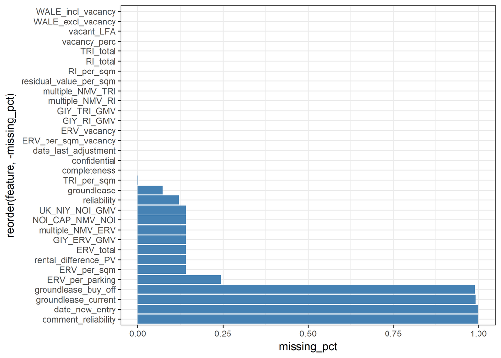

```r
  ## plot missing values
  missing_values <- df_XL %>% summarize_all(funs(sum(is.na(.))/n()))
  missing_values <- gather(missing_values, key="feature", value="missing_pct")
  missing_values[75:nrow(missing_values),] %>%
    ggplot(aes(x=reorder(feature,-missing_pct),y=missing_pct)) +
    geom_bar(stat="identity",fill="steelblue")+
    coord_flip()+theme_bw()
```

# 2. TRANSACTION RELATED DATA

First we subset the data to only include reliable / complete observations.

```r
  ## exclude missing IDs
  df_XL <- dplyr::filter(df_XL, BOG_ID > 0)
  print(paste0("Total number of observations: ", nrow(df_XL)))
```

```
## [1] "Total number of observations: 1143"
```

#### Transactions

Next we prepare variables closely relarted to our dependent variable that are mandatory. These are:

- Net transaction price (< 100 EUR are usually as non arm’s length transactions and are excluded)
- Transaction date (year / quarter)
- Geocoordinates

```r
  ## Filter out those with missing transaction prices or unreasonable numbers
  df_XL <- dplyr::filter(df_XL, purchase_price_net > 100)
  df_XL <- dplyr::filter(df_XL, purchase_price_net < 100000000)
  df_XL <- dplyr::filter(df_XL, TRI_per_sqm >= 30)

  # Transaction date to obtain transaction year and quarter
  df_XL$year_transaction <- as.numeric(format(as.Date(df_XL$transfer_date, format="%d/%m/%Y"),"%Y"))
  df_XL$month_transaction <- as.numeric(format(as.Date(df_XL$transfer_date, format="%d/%m/%Y"),"%m"))
  df_XL$half_transaction <- ((df_XL$month_transaction - 1) %/% 6) + 1
  df_XL$halfyear_transaction <- paste(df_XL$year_transaction, df_XL$half_transaction, sep = ".")
  df_XL$qtr_transaction <- ((df_XL$month_transaction - 1) %/% 3) + 1
  df_XL$yq_transaction <- paste(df_XL$year_transaction, df_XL$qtr_transaction, sep = ".")

  ## Geocoordinate
  df_XL <- dplyr::filter(df_XL, housenumber > 0)
  df_XL <- dplyr::filter(df_XL, postcode > 0)
  df_XL <- dplyr::filter(df_XL, longitude > 0)
  df_XL <- dplyr::filter(df_XL, latitude > 0)

  ## Output
  print(paste0("Total observations: ", nrow(df_XL)))
```

```
## [1] "Total observations: 1111"
```

#### Subset Period

The turbulent period around the economic crisis of 2008-2009 is excluded from the analysis.

```r
  ## limit timespan of transactions
  df_XL <- dplyr::filter(df_XL,  year_transaction > 2009)

  ## distribution transaction dates (year)
  # df_XL %>% rowwise() %>%
  #   group_by(year_transaction) %>%
  #   dplyr::summarise(no_of_transactions = length(year_transaction))

  ## distribution transaction dates (halfyear)
  df_XL %>% rowwise() %>%
    group_by(halfyear_transaction) %>%
    dplyr::summarise(no_of_transactions = length(halfyear_transaction))
```

```
## # A tibble: 17 x 2
##    halfyear_transaction no_of_transactions
##    <chr>                             <int>
##  1 2010.1                               15
##  2 2010.2                               22
##  3 2011.1                               18
##  4 2011.2                               25
##  5 2012.1                               13
##  6 2012.2                               15
##  7 2013.1                               21
##  8 2013.2                               66
##  9 2014.1                               31
## 10 2014.2                               66
## 11 2015.1                               55
## 12 2015.2                              164
## 13 2016.1                              152
## 14 2016.2                               95
## 15 2017.1                              119
## 16 2017.2                              154
## 17 2018.1                               31
```

```r
  ## Output
  print(paste0("Total observations: ", nrow(df_XL)))
```

```
## [1] "Total observations: 1062"
```

#### Temporary savepoint

```r
  tail(df_XL)
  try(sqlDrop(db.conn, "tbl3_data_prepared", errors = TRUE))
  sqlSave(db.conn, df_XL, tablename = "tbl3_data_prepared", append = FALSE,
          rownames = FALSE, colnames = FALSE, nastring = NA)
```

# 3. BUILDING FACTORS

We perform a number of preparation exercises on the building data. Variables obtained are as follows:

- Building Age
- Building size
- Parking spots
- Building height
- Energy label

#### Building age

We start with the building age. The age of a property (proxy for quality) is represented in three different ways:

- dummy periods
- year construction / last renovation
- effective age

```r
  ## cap minimum year of construction
  df_XL <- df_XL %>% dplyr::rowwise() %>%
           dplyr::mutate(year_of_construction =
                         ifelse(year_of_construction < 1900, 1900, year_of_construction))
  df_XL <- df_XL %>% dplyr::rowwise() %>%
           dplyr::mutate(year_last_renovation =
                         ifelse(year_last_renovation < 1900, 1900, year_last_renovation))

  ## Year built or renovation
  df_XL <- df_XL %>% dplyr::rowwise() %>%
           dplyr::mutate(year_built_or_renov =
                         ifelse(year_last_renovation > 0 && !is.na(year_last_renovation),
                                year_last_renovation,
                                year_of_construction))


  ## calculate age
  df_XL <- df_XL %>% dplyr::rowwise() %>%
           dplyr::mutate(age = year_transaction - year_of_construction)

  ## calculate effective age
  df_XL <- df_XL %>% dplyr::rowwise() %>%
           dplyr::mutate(effective_age = year_transaction - year_built_or_renov)

  ## Max effective age of 0
  df_XL <- df_XL %>%
           dplyr::mutate(effective_age = max(0, effective_age))
  df_XL <- df_XL %>%
           dplyr::mutate(age = max(0, age))

  ## building periods (like funda business)
  df_XL <- df_XL %>%
           dplyr::mutate(building_period =
                    ifelse(year_of_construction < 1906, "before_1906",
                    ifelse(year_of_construction >= 1906 && year_of_construction < 1931, "1906-1930",
                    ifelse(year_of_construction >= 1931 && year_of_construction < 1945, "1931-1944",
                    ifelse(year_of_construction >= 1945 && year_of_construction < 1960, "1945-1959",
                    ifelse(year_of_construction >= 1960 && year_of_construction < 1971, "1960-1970",
                    ifelse(year_of_construction >= 1971 && year_of_construction < 1981, "1971-1980",
                    ifelse(year_of_construction >= 1981 && year_of_construction < 1991, "1981-1990",
                    ifelse(year_of_construction >= 1991 && year_of_construction < 2001, "1991-2000",
                    ifelse(year_of_construction >= 2001 && year_of_construction <= 2010, "2001-2010",
                    ifelse(year_of_construction > 2010, "after_2010",NA)))))))))))

  ## building periods that take into account year last renovation
  df_XL <- df_XL %>%
           dplyr::mutate(building_period_renov =
                    ifelse(year_built_or_renov < 1906, "before_1906",
                    ifelse(year_built_or_renov >= 1906 && year_built_or_renov < 1931, "1906-1930",
                    ifelse(year_built_or_renov >= 1931 && year_built_or_renov < 1945, "1931-1944",
                    ifelse(year_built_or_renov >= 1945 && year_built_or_renov < 1960, "1945-1959",
                    ifelse(year_built_or_renov >= 1960 && year_built_or_renov < 1971, "1960-1970",
                    ifelse(year_built_or_renov >= 1971 && year_built_or_renov < 1981, "1971-1980",
                    ifelse(year_built_or_renov >= 1981 && year_built_or_renov < 1991, "1981-1990",
                    ifelse(year_built_or_renov >= 1991 && year_built_or_renov < 2001, "1991-2000",
                    ifelse(year_built_or_renov >= 2001 && year_built_or_renov <= 2010, "2001-2010",
                    ifelse(year_built_or_renov > 2010, "after_2010",NA)))))))))))

  ## output
  print(paste0("Total observations: ", nrow(df_XL)))
```

```
## [1] "Total observations: 1062"
```

#### Floor size (LFA)

```r
  ## show observations unlikely floor size
  df_XL <- dplyr::filter(df_XL, !is.na(total_LFA) && total_LFA > 10)

  # ## total LFA cannot be zero
  # df_XL <- df_XL %>% rowwise() %>%
  #          dplyr::mutate(total_LFA = ifelse(total_LFA < 10, NA, total_LFA))

  ## we can now also determine price of the property per m2
  df_XL <- df_XL %>%  rowwise() %>%
           dplyr::mutate(price_per_sqm = purchase_price_net/total_LFA)

  ## output
  print(paste0("Total observations: ", nrow(df_XL)))
```

```
## [1] "Total observations: 1062"
```

#### Parking spots

If ERV per parking as input, then cannot be zero.

```r
  ## assumption replace parking NA by 0
  df_XL <- df_XL %>% rowwise() %>%
           dplyr::mutate(parking_spots = ifelse(is.na(parking_spots), 0, parking_spots))

  ## manually check when there is ERV but no parking

  ## output
  print(paste0("Total observations: ", nrow(df_XL)))
```

```
## [1] "Total observations: 1062"
```

#### Building height

Missing building heights are filled based on counting floors on images. Remainder median substituted.

```r
  ## make building heights NA if below 3m
  df_XL <- df_XL %>% rowwise() %>%
           dplyr::mutate(building_height = ifelse(building_height < 3 , NA, building_height))

  ## If missing mean substitude
  df_XL <- df_XL %>% dplyr::group_by(wijk) %>%
           dplyr::mutate(building_height = ifelse(is.na(building_height),
                                                  median(building_height, na.rm=T),
                                                  building_height))

      ## if wijk not available use municipality
      df_XL <- df_XL %>% dplyr::group_by(gemeente) %>%
               dplyr::mutate(building_height = ifelse(is.na(building_height),
                                                      median(building_height, na.rm=T),
                                                      building_height))

      ## if municipality not available use corop
      df_XL <- df_XL %>% dplyr::group_by(COROP_region) %>%
               dplyr::mutate(building_height = ifelse(is.na(building_height),
                                                      median(building_height, na.rm=T),
                                                      building_height))

  ## output
  print(paste0("Total observations: ", nrow(df_XL)))
```

```
## [1] "Total observations: 1062"
```

#### Energy label

```r
  ## simple mean sustitute
  df_XL <- df_XL %>% dplyr::group_by(building_period_renov) %>%
           dplyr::mutate(EP_energieklasse = ifelse(is.na(EP_energieklasse),
                         names(table(EP_energieklasse))[which.max(table(EP_energieklasse))],
                         EP_energieklasse))

  ## output
  print(paste0("Total observations: ", nrow(df_XL)))
```

```
## [1] "Total observations: 1062"
```

#### Temporary savepoint

```r
  tail(df_XL)
  try(sqlDrop(db.conn, "tbl3_data_prepared", errors = TRUE))
  sqlSave(db.conn, df_XL, tablename = "tbl3_data_prepared", append = FALSE,
          rownames = FALSE, colnames = FALSE, nastring = NA)
```

# 4. LEASE FACTORS

We perform a number of preparation exercises on the Lease data. Variables obtained are as follows:

- Vacancy percentage
- Rents
- Lease Terms
- Other

#### Vacancy percentage

Vacancy percentage based in m2 vacant area and let.

```r
  # ## assume let m2 null = 0
  # df_XL <- df_XL %>% rowwise() %>%
  #          dplyr::mutate(let_LFA = ifelse(is.null(let_LFA), 0, let_LFA))
  #
  # ## assume vacancy m2 null = 0
  # df_XL <- df_XL %>% rowwise() %>%
  #          dplyr::mutate(vacant_LFA = ifelse(is.null(vacant_LFA), 0, vacant_LFA))
  #
  # ## estimate vacancy based on total LFA + vacant
  # df_XL <- df_XL %>% rowwise() %>%
  #          dplyr::mutate(vacancy_perc = vacant_LFA / total_LFA)

  ## output
  print(paste0("Total observations: ", nrow(df_XL)))
```

```
## [1] "Total observations: 1062"
```

#### Rents

- ERV parking
- Rental income (RI)
- Estimated Rental Value (ERV)
- Theoretical Rental Income (THI)
- Estimated Rental Value Vacancy

*Rental Income*

```r
  #   ## if vacancy not 100%, then likely that RI is zero. Check input manually
  #   df_XL %>% dplyr::filter(RI_total > 0 && let_LFA == 0)
  #   df_XL <- df_XL %>% rowwise() %>%
  #            dplyr::mutate(RI_per_sqm = ifelse(RI_total == 0, 0,
  #                                       ifelse(RI_total > 0 && let_LFA != 0,
  #                                              RI_total/let_LFA,
  #                                              NA)))
  #
  #   ## RI per sqm equals RI total / let area
  #   df_XL <- df_XL %>% rowwise() %>%
  #            dplyr::mutate(RI_per_sqm = ifelse(RI_total == 0, 0,
  #                                       ifelse(RI_total > 0 && let_LFA != 0,
  #                                              RI_total/let_LFA,
  #                                              NA)))

  ## output
  print(paste0("Total observations: ", nrow(df_XL)))
```

```
## [1] "Total observations: 1062"
```

*Estimated Rental Value*

The ERV is not complete and is excluded from the analysis (for now)

```r
  ## if ERV is 0 then missing
  # df_XL %>% dplyr::filter(ERV_total == 0)
  df_XL <- df_XL %>% rowwise() %>%
           dplyr::mutate(ERV_total = ifelse(ERV_total == 0 , NA, ERV_total))

  ## ERV per sqm = ERV total / let area (excl parking)
  df_XL <- df_XL %>% rowwise() %>%
           dplyr::mutate(ERV_per_sqm = ifelse(ERV_total > 0, ERV_total/total_LFA, NA))

  ## output
  print(paste0("Total observations: ", nrow(df_XL)))
```

```
## [1] "Total observations: 1062"
```

*Estimated Rental Value Vacancy*

Note to self: ERV vacancy does not have to equal m2 vacancy * ERV per m2

```r
  # ## if filled in negative make positive
  # df_XL <- df_XL %>% rowwise() %>%
  #          dplyr::mutate(ERV_vacancy = abs(ERV_vacancy))
  #
  # ## if vacancy is 0% then no ERV and if na then na
  # df_XL <- df_XL %>% rowwise() %>%
  #          dplyr::mutate(ERV_vacancy = ifelse(is.na(vacancy_perc), NA,
  #                                      ifelse(vacancy_perc == 0, 0,
  #                                             ERV_vacancy)))
  #
  # ## if vacancy but no ERV vacancy fill with m2 vacancy * ERV per m2
  # df_XL <- df_XL %>% rowwise() %>%
  #          dplyr::mutate(ERV_vacancy =
  #                        ifelse(is.na(ERV_vacancy), vacant_LFA * ERV_per_sqm,
  #                        ifelse(vacant_LFA > 0 && ERV_vacancy == 0 && ERV_per_sqm > 0,
  #                               ERV_per_sqm * vacant_LFA,
  #                               ERV_vacancy)))
  #
  # ## ERV vacancy per m2
  # df_XL <- df_XL %>% rowwise() %>%
  #          dplyr::mutate(ERV_per_sqm_vacancy = ifelse(ERV_vacancy > 0, ERV_total/vacant_LFA,
  #                                              ifelse(ERV_vacancy == 0, 0, NA)))

  ## output
  print(paste0("Total observations: ", nrow(df_XL)))
```

```
## [1] "Total observations: 1062"
```

*Theoretical Rental Income*

```r
  # ## CALC: TRI = RI + ERV vacancy if NA
  # df_XL %>% dplyr::filter(TRI_total == 0)
  # df_XL <- df_XL %>% rowwise() %>%
  #          dplyr::mutate(TRI_total = RI_total + ERV_vacancy)
  #
  # ## CALC: TRI per sqm = TRI total / total LFA (excl parking)
  # df_XL <- df_XL %>% rowwise() %>%
  #          dplyr::mutate(TRI_per_sqm = TRI_total/total_LFA)

  ## output
  print(paste0("Total observations: ", nrow(df_XL)))
```

```
## [1] "Total observations: 1062"
```

*Estimated Rental Value parking*

```r
  # ## ERV per parking
  # df_XL <- df_XL %>% rowwise() %>%
  #          dplyr::mutate(ERV_per_parking = ifelse(parking_spots==0, 0, ERV_per_parking))
  #
  # ## ERV total parking formula
  # df_XL <- df_XL %>% rowwise() %>%
  #          dplyr::mutate(ERV_parking = parking_spots * ERV_per_parking)
  #
  # ## RI per sqm equals RI total / let area (excl. parking)
  # df_XL <- df_XL %>% rowwise() %>%
  #          dplyr::mutate(RI_per_sqm_excl_parking = ifelse(let_LFA > 0,
  #                                                         sum(RI_total, -ERV_parking, na.rm=T)/let_LFA,
  #                                                         RI_per_sqm))
  #
  # ## ERV per sqm equals ERV total / total area (excl. parking)
  # df_XL <- df_XL %>% rowwise() %>%
  #          dplyr::mutate(ERV_per_sqm_excl_parking = ifelse(ERV_total > 0,
  #                                                          sum(ERV_total, -ERV_parking, na.rm=T)/total_LFA,
  #                                                          ERV_per_sqm))
  #
  # ## THI per sqm equals TRI total / total area (excl. parking)
  # df_XL <- df_XL %>% rowwise() %>%
  #          dplyr::mutate(TRI_per_sqm_excl_parking = ifelse(TRI_total > 0,
  #                                                          sum(TRI_total, -ERV_parking, na.rm=T)/total_LFA,
  #                                                          TRI_per_sqm))

  ## output
  print(paste0("Total observations: ", nrow(df_XL)))
```

```
## [1] "Total observations: 1062"
```

#### Lease Terms

```r
  # ## if 100% vacancy then WALE = 0
  # df_XL <- df_XL %>% rowwise() %>%
  #          dplyr::mutate(WALE_incl_vacancy = ifelse(is.na(WALE_incl_vacancy) && let_LFA == 0,
  #                                                   0, WALE_incl_vacancy)) %>%
  #          dplyr::mutate(WALE_excl_vacancy = ifelse(is.na(WALE_excl_vacancy) && let_LFA == 0,
  #                                                   0, WALE_excl_vacancy))
  #
  # ## WALE incl
  # df_XL <- df_XL %>% rowwise() %>%
  #          dplyr::mutate(WALE_incl_vacancy = ifelse(is.na(WALE_incl_vacancy) && TRI_total != 0,
  #                                                   (WALE_excl_vacancy * RI_total) / TRI_total,
  #                                                   WALE_incl_vacancy))
  #
  # ## WALE excl
  # df_XL <- df_XL %>% rowwise() %>%
  #          dplyr::mutate(WALE_excl_vacancy = ifelse(is.na(WALE_excl_vacancy) && RI_total != 0,
  #                                                   (WALE_incl_vacancy * TRI_total) / RI_total,
  #                                                   WALE_excl_vacancy))

  ## output
  print(paste0("Total observations: ", nrow(df_XL)))
```

```
## [1] "Total observations: 1062"
```

#### Rental Difference

```r
  ## if no RI then WALE = 0 (use TRI??)
  df_XL <- df_XL %>% rowwise() %>%
           dplyr::mutate(PV_rental_diff = ifelse(ERV_total > 0 && WALE_excl_vacancy > 0,
                                                (ERV_total - RI_total) * (1 + 0.06) ^ -WALE_excl_vacancy,
                                          ifelse(WALE_excl_vacancy == 0, 0, NA)))

  ## if no RI then WALE = 0
  df_XL <- df_XL %>% rowwise() %>%
           dplyr::mutate(underrented = ifelse (PV_rental_diff > 0, "UNDER",
                                       ifelse (PV_rental_diff > -1000 && PV_rental_diff < 1000,
                                               "MARKET", "OVER" )))

  ## eyeball missing values
  # df_XL %>% dplyr::filter(is.na(PV_rental_diff))
  # df_XL %>% dplyr::filter(is.na(underrented))

  ## if missing assume market and add id (TO DO)
  df_XL <- df_XL %>% rowwise() %>%
           dplyr::mutate(error_id = ifelse(is.na(underrented), 1, 0)) %>%
           dplyr::mutate(error_var = ifelse(is.na(underrented), "underrented", NA)) %>%
           dplyr::mutate(underrented = ifelse(is.na(underrented), "MARKET", underrented))

  ## output
  print(paste0("Total observations: ", nrow(df_XL)))
```

```
## [1] "Total observations: 1062"
```

#### Temporary savepoint

```r
  tail(df_XL)
  try(sqlDrop(db.conn, "tbl3_data_prepared", errors = TRUE))
  sqlSave(db.conn, df_XL, tablename = "tbl3_data_prepared", append = FALSE,
          rownames = FALSE, colnames = FALSE, nastring = NA)
```

# 5. LOCATION FACTORS

Location factors covered are

- Accessibility
- Ammenities (walkscore)
- Liveability (Leefbaarometer)
- Other

#### Accessibility

The different types of accessibility covered are:

- nearest station (min walking)
- highway access (min driving)

```r
  # ## TEMP - done in management
  # df_XL <- df_XL %>% rowwise %>%
  #          dplyr::mutate(train_station_duration = ifelse(train_station_name %in% "ZERO_RESULTS",
  #                                                        99, train_station_duration))  %>%
  #          dplyr::mutate(train_station_distance = ifelse(train_station_name %in% "ZERO_RESULTS",
  #                                                        9999, train_station_distance))  %>%
  #          dplyr::mutate(train_station_intercity = ifelse(train_station_name %in% "ZERO_RESULTS",
  #                                                         FALSE, train_station_intercity))

  ## output
  print(paste0("Total observations: ", nrow(df_XL)))
```

```
## [1] "Total observations: 1062"
```

#### Ammenities

Ammenities are measured by Walkscore

```r
  ## output
  print(paste0("Total observations: ", nrow(df_XL)))
```

```
## [1] "Total observations: 1062"
```

#### Liveability

Liveability is measured through the leefbaarometer

```r
  ## output
  print(paste0("Total observations: ", nrow(df_XL)))
```

```
## [1] "Total observations: 1062"
```

#### Other

- city category
- centrality
- type of district

```r
  ## output
  print(paste0("Total observations: ", nrow(df_XL)))
```

```
## [1] "Total observations: 1062"
```

```r
  tail(df_XL)
  try(sqlDrop(db.conn, "tbl3_data_prepared", errors = TRUE))
  sqlSave(db.conn, df_XL, tablename = "tbl3_data_prepared", append = FALSE,
          rownames = FALSE, colnames = FALSE, nastring = NA)
```

# 6. FINALIZE DATA / WRITE TO DATABASE

Finally, we remove all of the unnecessary field and rename some variables.

```r
  # Transform:  Limit field names
  df_XL <- dplyr::select(.data=df_XL,

       ## TRANSACTION INFO
          BOG_ID,                 # unique ID to link back to database
          purchase_price = purchase_price_net,     # dependent variable
          transfer_date,          # transaction date (finest granularity)
          year_transaction,       # transaction year (wide granularity)
          halfyear_transaction,   # transaction halfyear
          latitude,               # lattitude
          longitude,              # longitude
       ## BUILDING FACTORS
          year_built =  year_of_construction, # year built
          year_last_renovation,   # year last renovation
          year_built_or_renov,    # year built or last renovated
          age,                    # Age
          effective_age,          # years between transaction and last renovation
          building_period,        # year built
          building_period_renov,  # distinct buiding periods
          total_LFA,              # building size
          building_height,        # building height
          EP_energieklasse,       # energy performance (green building)
          parking_spots,          # number of parking spots (inside and/or outside)
       ## LOCATION FACTORS
          COROP_region,           # often used for statistical research
          city_category,          # large or small city
          centrality,             # walking distance of intercity station
          CW_district_type,       # indicator: kantoorgebied, bedrijfsgebied, gemengd, other.
          walkscore,              # score for ammenities with walkscore api
          train_station_duration, # min walking to nearest station
          highway_access_duration,# min driving to nearest highway access
          lbm_total_score,        # leefbaarometer (later split up)
       ## LEASE FACTORS
          vacancy = vacancy_perc, # amount of LFA vacant at time of sale (as percent of total LFA)
          TRI_per_sqm,            # total theoretical rental income (includes value for vacancy)
          WALE = WALE_incl_vacancy,      # remaining lease term including vacancy m2
          underrented             # rental income above or under market rent
                                  )
```

We then write the data back to the database as *tbl3_data_prepared*.

```r
  ## write back to database
  try(sqlDrop(db.conn, "tbl3_data_prepared", errors = TRUE))
  sqlSave(db.conn, df_XL, tablename = "tbl3_data_prepared", append = FALSE,
          rownames = FALSE, colnames = FALSE, nastring = NA)
```

We finish the *Data Preperation* phase of our analysis by closing the connection to the database.

```r
  ## close db connection
  odbcCloseAll()
  remove(db.conn)
  rm(list = ls())
```

> Go back to top